# ISYE 6501

2022-09-04

# Submission HW2 | Fall 22

- Ashish Dhiman | ashish.dhiman@gatech.edu
- Abhinav Arun | aarun60@gatech.edu
- Anshit Verma | averma373@gatech.edu

*Analysis Notes are marked with Red header: #Analysis

```r
set.seed(61)

# imports
library(ggplot2)
library(cowplot)
library(reshape2)
library(factoextra)
library(kknn)
library(pROC)
```

## Read Data

```r
org_cc_data <- read.table(file = './data 3.1/credit_card_data-headers.txt', sep = "\t", header = TRUE)
dim(org_cc_data)
```

```
## [1] 654  11
```

## Question 3.1

### Part 1: Cross Validation for finding best knn model

Here we perform 5 fold cross validation, and follow the following pseudo code:

0. Divide the data into train,test (where test is final data used for evaluation)
1. Divide the combined train and validation data into 5 equal parts
2. Choose i’th part as test data and train knn model on the rest 4 parts
   1. Find the optimal threshold using the ROC curve
   2. With this optimal threshold find accuracy on test set
3. Repeat step 2 but slide i to the next part
4. When all parts are rotated into the test set, calculate the measure for accuracy of model:
   1. Mean test accuracy across 5 folds
   2. Min test accuracy across the 5 folds (optional)

**We repeat the above 1-4 steps for different k values, to find the best model(or choice of k)**

### Step 0:

```r
set.seed(77)

#split data into 70% train, 15% validation and 15% test
df_copy = org_cc_data
df_copy$split_i <- sample(100, size = nrow(df_copy), replace = TRUE)

df_copy$split = "train"
df_copy$split[70 < df_copy$split_i] = "valid"
df_copy$split[85 < df_copy$split_i] = "test"

summary_df = aggregate(df_copy$R1,list(df_copy$split),
          FUN = function(x) c(mean = mean(x), proportion = length(x)/nrow(df_copy)))
print.data.frame(summary_df)
```

```
##   Group.1    x.mean x.proportion
## 1    test 0.4947368    0.1452599
## 2   train 0.4434389    0.6758410
## 3   valid 0.4529915    0.1788991
```

```r
df_train = df_copy[df_copy$split=="train",]
dim(df_train)
```

```
## [1] 442  13
```

```r
df_valid = df_copy[df_copy$split=="valid",]
dim(df_valid)
```

```
## [1] 117  13
```

```r
df_test= df_copy[df_copy$split=="test",]
dim(df_test)
```

```
## [1] 95 13
```

### Step 1:

```r
#Split the combined (train and validation) into 5 parts for CV
df_cv = rbind(df_train,df_valid)
dim(df_cv)
```

```
## [1] 559  13
```

```r
df_copy = df_cv
df_copy$cross_validation_i <- sample(5, size = nrow(df_copy), replace = TRUE)

summary_df = aggregate(df_copy$R1,list(df_copy$cross_validation_i),
          FUN = function(x) c(mean = mean(x), proportion = length(x)/nrow(df_copy)))
print.data.frame(summary_df)
```

```
##   Group.1    x.mean x.proportion
## 1       1 0.4568966    0.2075134
## 2       2 0.4766355    0.1914132
## 3       3 0.4695652    0.2057245
## 4       4 0.3893805    0.2021467
## 5       5 0.4351852    0.1932021
```

**#Analysis**

The above summary shows the mean of R1 and relative size of each fold. Ideally for all the folds this should be 45% mean and 20% proportion, but we see minor deviations in individual folds due to random sampling.

```r
#Function to train model and return prediction probabilities on test
train_test_i = function(df_train,df_test, k0 = 5){
  f = R1~A1+A2+A3+A8+A9+A10+A11+A12+A14+A15
  model = kknn(f,train = df_train,test = df_test,k=k0,kernel="rectangular",scale = TRUE)
  return (fitted(model))
}

# decide best threshold
best_threshold = function(pred_prob, df_test=org_cc_data){
  myroc <- roc(df_test$R1,as.numeric(unlist(pred_prob)), smooth=FALSE)
  print(paste("AUC is",auc(myroc)))
  #plot(myroc, auc.polygon=TRUE)
  return (coords(myroc,x="best")["threshold"][[1]])
}

#Accuracy for best threshold
acc_func = function(y_act, pred_probs, thresh = 0.5){
  y_pred = lapply(pred_probs, function(x) if(x>=thresh) 1 else 0)
  y_pred = as.numeric(unlist(y_pred))
  acc_overall = sum(y_act == y_pred)/length(y_act)
  acc_overall = round(acc_overall,4)* 100
  return (acc_overall)
}
```

### Step 2

```r
#Train model and test on ith group
cv_function_i = function(df, test_index_choice,k_choice){
  print("")
  print (paste("test index for CV Fold",test_index_choice))
  #split data into train and test
  mask_test_i = df$cross_validation_i == test_index_choice
  df_train = df[!mask_test_i,]
  df_test = df[mask_test_i,]
  print (paste("Train,Test Size =",nrow(df_train),nrow(df_test)))
  #train and get probaility predictions on test model
  test_probabilities = train_test_i(df_train,df_test, k0 = k_choice)

  #get best threshold for test probabilities
  ti = best_threshold(test_probabilities, df_test = df_test)
  if (length(ti) >1){
    ti = ti[[1]] #select 1st when there are multiple optimal thresholds
  }
  print (paste("Best threshold is",ti))
  #get test accuracy
  y_act = df_test$R1
  #print (paste("Length of Test Probabilities",nrow(df_test),length(test_probabilities)))
  return (acc_func(y_act = y_act, pred_probs = test_probabilities, thresh = ti))
}
```

```r
#Test fucntion with a sample i
cv_function_i(df = df_copy, test_index_choice = 1, k_choice = 16)
```

```
## [1] ""
## [1] "test index for CV Fold 1"
## [1] "Train,Test Size = 443 116"
```

```
## [1] "AUC is 0.880503144654088"
## [1] "Best threshold is 0.25"
```

```
## [1] 82.76
```

### Step 3

```r
#CV function: pass k, return test accuracy for all folds
cv_function = function(df = df_copy,k_choice = 5){
  print("----------------------------------------------")
  print(paste("For k value",k_choice))
  cv_accuracy = lapply(seq(1,5), function(x) cv_function_i(df=df_copy,x,k_choice))
  print("----------------------------------------------")
  return (cv_accuracy)
}
```

```r
#Test function with a sample k
cv_accuracy = cv_function(df = df_copy,k_choice = 16)
```

```
## [1] "----------------------------------------------"
## [1] "For k value 16"
## [1] ""
## [1] "test index for CV Fold 1"
## [1] "Train,Test Size = 443 116"
## [1] "AUC is 0.880503144654088"
## [1] "Best threshold is 0.25"
## [1] ""
## [1] "test index for CV Fold 2"
## [1] "Train,Test Size = 452 107"
## [1] "AUC is 0.937324929971989"
## [1] "Best threshold is 0.46875"
## [1] ""
## [1] "test index for CV Fold 3"
## [1] "Train,Test Size = 444 115"
## [1] "AUC is 0.882817243472981"
## [1] "Best threshold is 0.25"
## [1] ""
## [1] "test index for CV Fold 4"
## [1] "Train,Test Size = 446 113"
## [1] "AUC is 0.9433465085639"
## [1] "Best threshold is 0.46875"
## [1] ""
## [1] "test index for CV Fold 5"
## [1] "Train,Test Size = 451 108"
## [1] "AUC is 0.905999302406697"
## [1] "Best threshold is 0.28125"
## [1] "----------------------------------------------"
```

```r
unlist(cv_accuracy)
```

```
## [1] 82.76 90.65 83.48 91.15 83.33
```

```r
mean(unlist(cv_accuracy))
```

```
## [1] 86.274
```

The values match the above test run values

### Step 4: Iterate on different models(i.e on different values of k) and use CV for best model

Here we differentiate two knn models, only using the k hyperparameter

```r
#Iterate over k and get mean test accuracy

end_k = 77 #almost half of test set size

acc_df <- data.frame(matrix(ncol = 0, nrow = length(seq(3,end_k,2))))
acc_df$k_kknn = seq(3,end_k,2)
mean_cv_acc_k = lapply(seq(3,end_k,2), function(x) mean(unlist(cv_function(df = df_copy,x))))
min_cv_acc_k = lapply(seq(3,end_k,2), function(x) min(unlist(cv_function(df = df_copy,x))))
sd_cv_acc_k = lapply(seq(3,end_k,2), function(x) sd(unlist(cv_function(df = df_copy,x))))
acc_df$mean_cv_accuracy = unlist(mean_cv_acc_k)
acc_df$min_cv_accuracy = unlist(min_cv_acc_k)
acc_df$sd_cv_accuracy = unlist(sd_cv_acc_k)
```

```r
acc_df
```

| k_kknn | mean_cv_accuracy | min_cv_accuracy | sd_cv_accuracy |
| --- | --- | --- | --- |
| 3 | 83.442 | 79.13 | 3.635790 |
| 5 | 85.930 | 82.76 | 3.064637 |
| 7 | 86.292 | 82.76 | 3.539939 |
| 9 | 85.376 | 82.41 | 3.814240 |
| 11 | 85.740 | 82.41 | 4.312633 |
| 13 | 86.284 | 82.76 | 3.506142 |
| 15 | 86.090 | 82.41 | 4.411366 |
| 17 | 86.256 | 82.76 | 4.453081 |
| 19 | 86.258 | 82.61 | 4.719721 |
| 21 | 86.446 | 82.61 | 4.816714 |

[output cut: 28 more lines]

**#Analysis**

The above dataframe has average CV accuracy, min CV accuracy and Std. Deviation of Accuracy for each k value tried. While average CV Accuracy is a typical performance measure, we have also retained min CV accuracy which is like a lower bound on the performance of models across various validation sets, and we can also use max of this min bound to find optimal k.

We have also kept standard deviation, such that we will be able to infer the variance of accuracy across cross folds. This is helpful because the maximum CV accuracy for different values across k varies in a very close interval (around 86.5 %) -> see graph below

#### Plot the accuracy with k (hyperparameter of knn), and find optimal k which maximizes accuracy

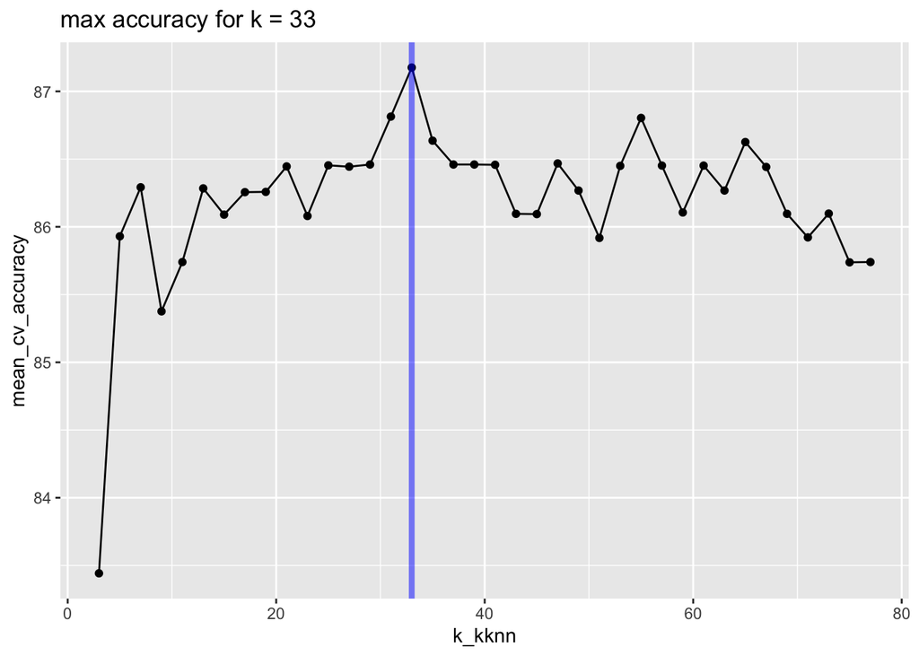

```r
ggplot(data = acc_df, aes(x = k_kknn, y = mean_cv_accuracy)) +
  geom_line() +geom_point() +
  geom_vline(xintercept = acc_df[which.max(acc_df$mean_cv_accuracy),1],
             color ="blue", size = 1.5, alpha = 0.5) +
  ggtitle(paste("max accuracy for k =",acc_df[which.max(acc_df$mean_cv_accuracy),1]))
```

```r
print (paste("max accuracy for k =",acc_df[which.max(acc_df$mean_cv_accuracy),1]))
```

```
## [1] "max accuracy for k = 33"
```

**#Analysis**

Here we see that for k = 33, we get maximum average CV accuracy of 87.18%.

However, as noted above the nuance to note here is that, for k > 25, accuracy mostly oscillates at almost the same range with delta of 1%. But since the standard deviation of max accuracy among cross folds is 4.47 itself, this choice of k becomes a little tricky. In other words, any k value above 25 seems appropriate, as the performance separation between the models is minimal

Another effect to note here is that, this optimal value of k, is also subject to the random sampling done to create the folds, and will change with a different random seed setting.

```r
acc_df[which.max(acc_df$mean_cv_accuracy),]
```

|  | k_kknn | mean_cv_accuracy | min_cv_accuracy | sd_cv_accuracy |
| --- | --- | --- | --- | --- |
| 16 | 33 | 87.176 | 82.76 | 4.4664 |

```r
train_valid_func = function(df_train, df_test, k_choice){
  print (paste("For k=",k_choice))
  #split data into train and test
  print (paste("Train,Test Size =",nrow(df_train),nrow(df_test)))
  #train and get probaility predictions on test model
  test_probabilities = train_test_i(df_train,df_test, k0 = k_choice)
  #get best threshold for test probabilities
  ti = best_threshold(test_probabilities, df_test = df_test)
  print (paste("Best threshold is",ti))
  #get test accuracy
  y_act = df_test$R1
  #print (paste("Length of Test Probabilities",nrow(df_test),length(test_probabilities)))
  return (acc_func(y_act = y_act, pred_probs = test_probabilities, thresh = ti))
}
```

Test the function for a sample value

```r
train_valid_func(df_train = df_train, df_test = df_valid, k_choice = 20)
```

```
## [1] "For k= 20"
## [1] "Train,Test Size = 442 117"
```

```
## [1] "AUC is 0.929834905660377"
## [1] "Best threshold is 0.475"
```

```
## [1] 88.03
```

#### Rebuild model with optimal k selected, for true test accuracy

- Train = Train + Validation
- Test = Test

```r
k_optimal = acc_df[which.max(acc_df$mean_cv_accuracy),1]
acc_optimal_k = train_valid_func(df_train = df_copy, df_test = df_test, k_choice = k_optimal)
```

```
## [1] "For k= 33"
## [1] "Train,Test Size = 559 95"
```

```
## [1] "AUC is 0.926640070921986"
## [1] "Best threshold is 0.348484848484849"
```

```r
print (paste("With optimal k value, Accuracy on test =",acc_optimal_k))
```

```
## [1] "With optimal k value, Accuracy on test = 87.37"
```

The above accuracy is a true(or best) measure/evaluation for our model

### Question 3.1, Part 2: Train, Validation and Test

### Find optimal k using training on train and maximising accuracy on validation

#### Run the train_valid_func function for variety of k values

```r
acc_df2 <- data.frame(matrix(ncol = 0, nrow = length(seq(3,end_k,2))))
acc_df2$k_kknn = seq(3,end_k,2)
acc = lapply(seq(3,end_k,2), function(x)
  train_valid_func(df_train = df_train, df_test = df_valid, k_choice = x))
acc_df2$acc_validation_set = unlist(acc)
```

#### Plot the accuracy values

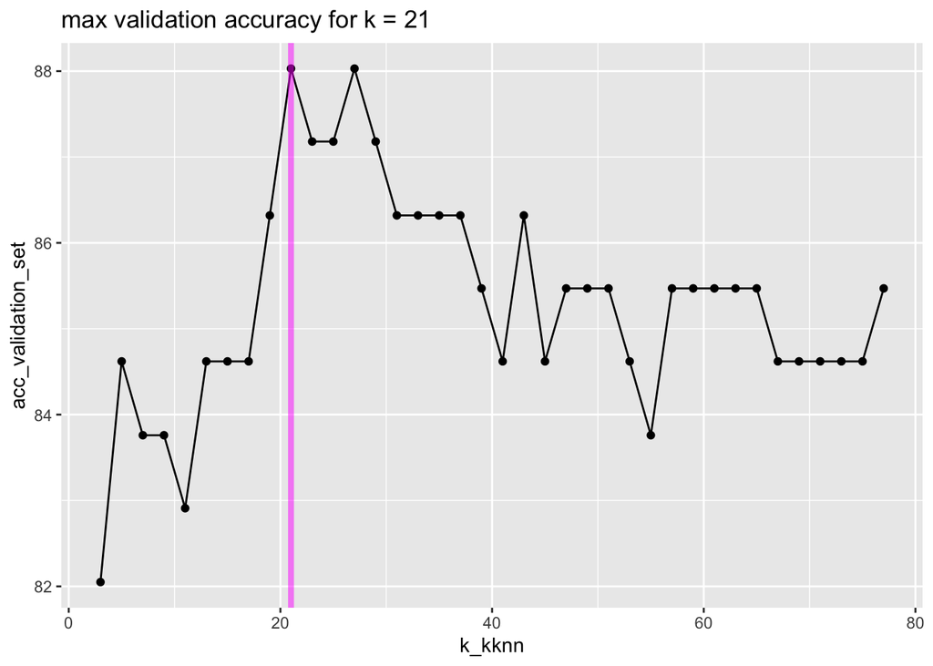

```r
ggplot(data = acc_df2, aes(x = k_kknn, y = acc_validation_set)) +
  geom_line() +geom_point() +
  geom_vline(xintercept = acc_df2[which.max(acc_df2$acc_validation_set),1],
             color ="magenta", size = 1.5, alpha = 0.5) +
  ggtitle(paste("max validation accuracy for k =",acc_df2[which.max(acc_df2$acc_validation_set),1]))
```

```r
print (paste("max validation accuracy for k =",acc_df2[which.max(acc_df2$acc_validation_set),1]))
```

```
## [1] "max validation accuracy for k = 21"
```

#### Rebuild model with optimal k, with

- Train = Train + Validation
- Test = Test

```r
k_optimal = acc_df2[which.max(acc_df2$acc_validation_set),1]
acc_optimal_k = train_valid_func(df_train = rbind(df_train,df_valid), df_test = df_test, k_choice = k_optimal)
```

```
## [1] "For k= 21"
## [1] "Train,Test Size = 559 95"
```

```
## [1] "AUC is 0.929521276595745"
## [1] "Best threshold is 0.452380952380952"
```

```r
print (paste("With optimal k value, Accuracy on test =",acc_optimal_k))
```

```
## [1] "With optimal k value, Accuracy on test = 88.42"
```

**#Analysis**

Note, that both the optimal k value here and the optimal accuracy value are different than part 1 above.

The test accuracy here is the true (or best available) evaluation of the model chosen by us.

However one might also argue that the optimal k values from both the approaches lie in a similar range, since any k value >25 can be chosen from cross validation too.

## Question 4.1

### Example 1: Market Segmentation/Retail Marketing

Clustering models are used for grouping customers with similar attributes and features into buckets. A typical use case of this approach is to segment the customers into groups, such that they can be better targeted for a spectrum of business activities like targeted advertising. Segmenting the market helps the business better spend their money in the right way. One real life example is from Google and how it uses various predictors to cluster users on various factors to show targeted advertisement.

**Predictor Variables (**$X_i$): Some of the key predictors are given below:

- *Search History*: This variable tracks user’s search history and helps in identifying what the user might me interested in. It can also help identify what the user wants in the market, for example if they are interested in the fuel efficiency or model or performance of a car.
- *Personal User Data*: User’s personal data plays a key role in clustering user based on their age, gender, etc. Showing ads which are relevant to he user helps in creating a better user experience.
- *Links Clicked*: This is a measure of user’s interaction with links available on the webpage. It helps with analyzing user behavior which helps in clustering on the basis of activity. Suppose a user searches for car but only interacts with links which lead to results from a certain brand of car. Determining this behavior will help in showing targeted ads from that brand to that particular user.
- *User Location*: This is a user’s location. This helps with serving geographical appropriate ads. It would lead to bad user experience if a user from India is shown an ad for a product which is available in USA.

## Question 4.2

```r
iris_data = read.table('./iris.txt', header = TRUE, sep='', dec='.')
head(iris_data,50)
dim(iris_data)
```

[output not shown]

### Exploratory Data Analysis (for getting the best predictor combinations)

```r
summary(iris_data)
```

```
##   Sepal.Length    Sepal.Width     Petal.Length    Petal.Width
##  Min.   :4.300   Min.   :2.000   Min.   :1.000   Min.   :0.100
##  1st Qu.:5.100   1st Qu.:2.800   1st Qu.:1.600   1st Qu.:0.300
##  Median :5.800   Median :3.000   Median :4.350   Median :1.300
##  Mean   :5.843   Mean   :3.057   Mean   :3.758   Mean   :1.199
##  3rd Qu.:6.400   3rd Qu.:3.300   3rd Qu.:5.100   3rd Qu.:1.800
##  Max.   :7.900   Max.   :4.400   Max.   :6.900   Max.   :2.500
##    Species
##  Length:150
##  Class :character
##  Mode  :character
##
##
##
```

```r
table(iris_data$Species)
```

```
##
##     setosa versicolor  virginica
##         50         50         50
```

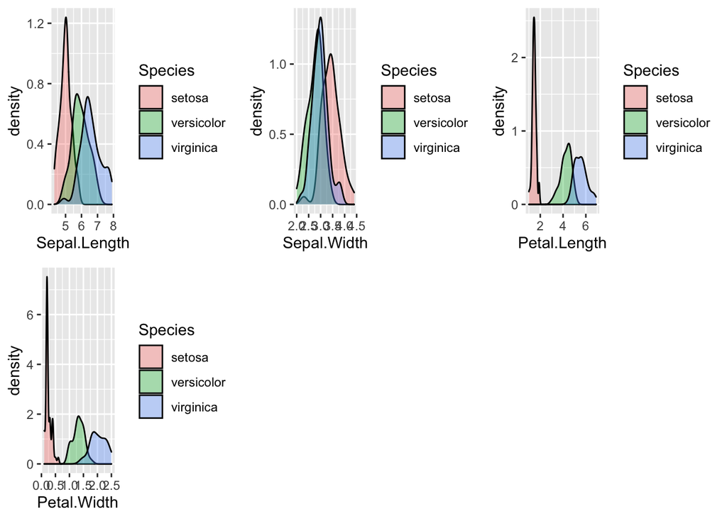

```r
# Density Plots
my_plots = lapply(colnames(iris_data), function(x){
  p = ggplot(iris_data, aes(fill = Species)) + aes_string(x)
  if(x!='Species') {
    p = p + geom_density(alpha=.34)
  }
})

plot_grid(plotlist = my_plots)
```

**#Analysis**

From the above distribution, we can make the following inferences: 1. Petal.Length and Petal.Width provide clear separation between the setosa vs the other classes. In clustering we expect these variables to be significantly lower in the cluster dominated by the ‘setosa’ classes. 2. We observe that while Sepal.Width and Sepal.Length have different central tendencies, they also show high degree of overlap between the different classes at the fringes.

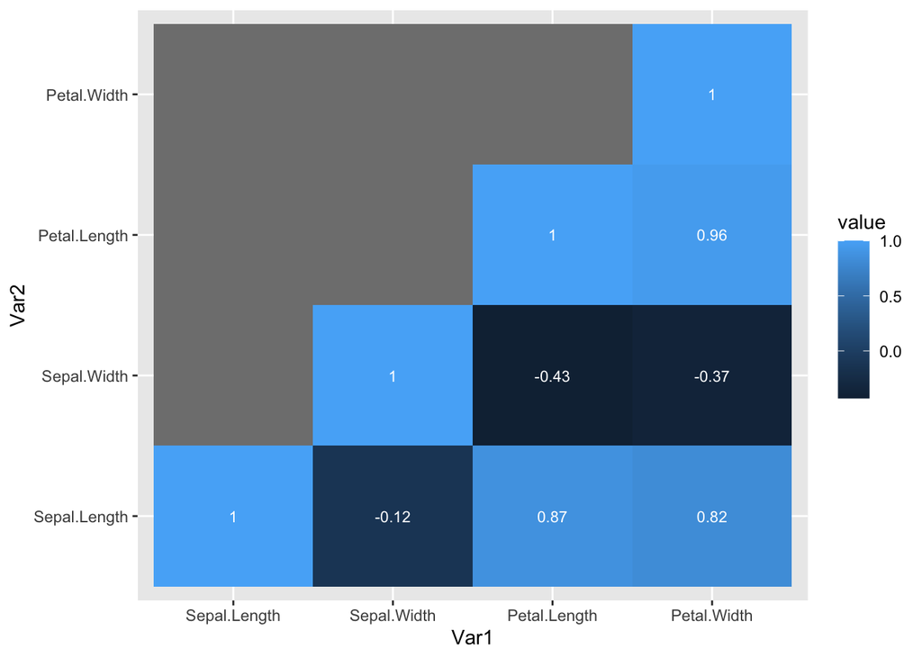

```r
# Correlation Matrix
cor_mat = round(cor(iris_data[,1:4]), 2)
cor_mat[upper.tri(cor_mat)] <- NA
melted_mat = melt(cor_mat)
ggplot(melted_mat, aes(x=Var1, y=Var2, fill=value)) +
  geom_tile() + geom_text(aes(Var1, Var2, label=value), color='white', size=3)
```

**#Analysis**

From the above matrix we observed the following: 1. Petal Length and Width are highly correlated 2. Sepal Length and Petal Width are highly correlated also 3. Sepal length and Sepal Width show negligible dependence 4. Sepal width is negatively correlated petal length and width

### Modelling

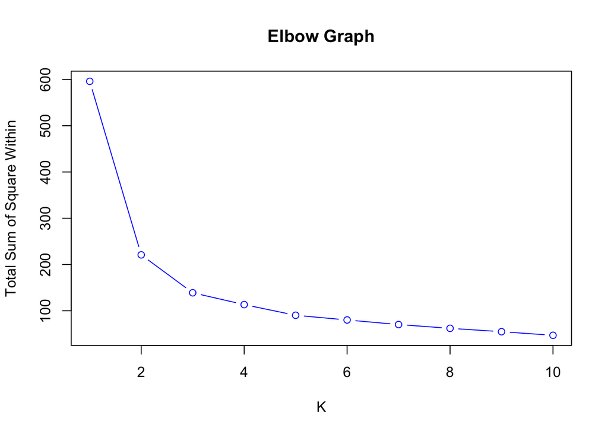

```r
# Calculation of best 'K' by elbow graph for total sum of squares within
elbow_graph_data <- data.frame(K=integer(), within_sum_of_square=double())
for(k in seq(1, 10, by=1)){
  km.res <- kmeans(as.matrix(scale(iris_data[,1:4])), k, nstart = 25)
  elbow_graph_data[nrow(elbow_graph_data) + 1, ] = c(k, km.res$tot.withinss)
}
plot(elbow_graph_data, type='b', ylab='Total Sum of Square Within', main='Elbow Graph', col='blue')
```

**#Analysis**

* From the above graph, we can see that increasing the value of ‘K’ beyond 4 yields very low marginal benefit. * Both 3 and 4 appear to be good values of ‘K’ and can be used depending on the use case. In this example, since we know that there are 3 classes, we expect 3 to be a more appropriate choice. (*Best value of k for our analysis*)

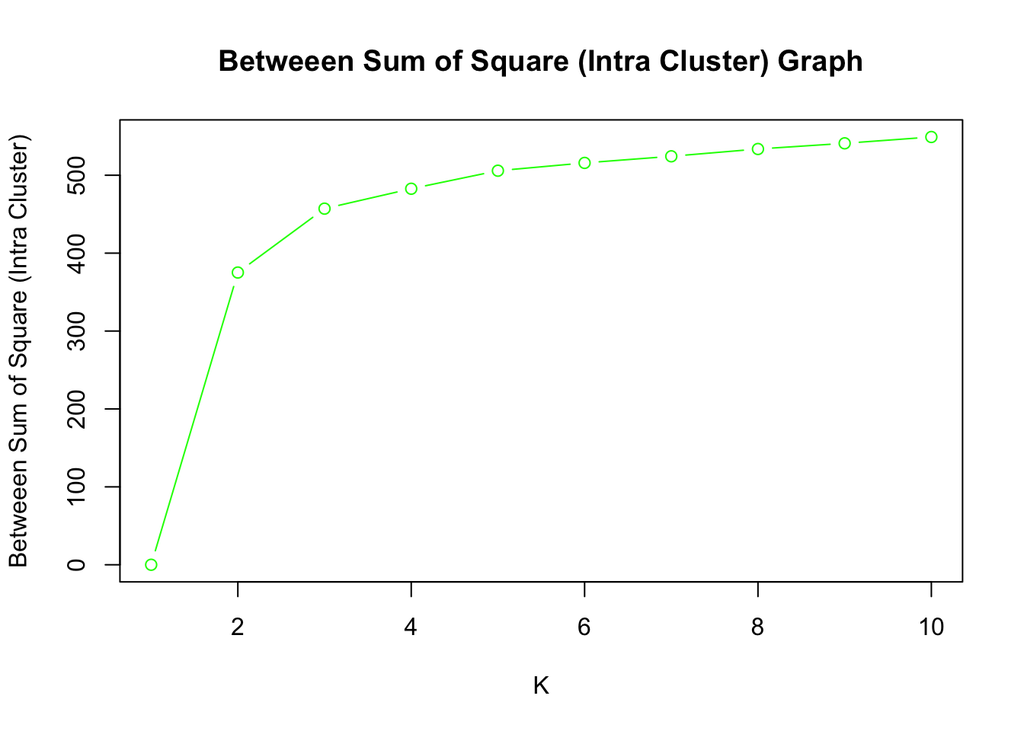

```r
# Other Method for determining best 'K' by sum of intra-cluster distance
bw_graph_data <- data.frame(K=integer(), between_sum_of_square=double())
for(k in seq(1, 10, by=1)){
  km.res <- kmeans(as.matrix(scale(iris_data[,1:4])), k, nstart = 25)
  bw_graph_data[nrow(bw_graph_data) + 1, ] = c(k, round(km.res$betweenss,2))
}
plot(bw_graph_data, type='b', ylab='Betweeen Sum of Square (Intra Cluster)', main='Betweeen Sum of Square (Intra Cluster) Graph', col='green')
```

**#Analysis**

* Similarly to elbow-graph, this plot also shows 3 and 4 to be good choices for ‘K’.

```r
confusion_matrix <- table(iris_data$Species, best_km$cluster)
confusion_matrix
```

```
##
##               1  2  3
##   setosa      0  0 50
##   versicolor 39 11  0
##   virginica  14 36  0
```

**#Analysis**

However in comparison to cluster 3 which is purely setosa; clusters 1 and 2 have a significant no. of data points of a different class. In other words, there is confusion between classes in clusters 1 and 2.

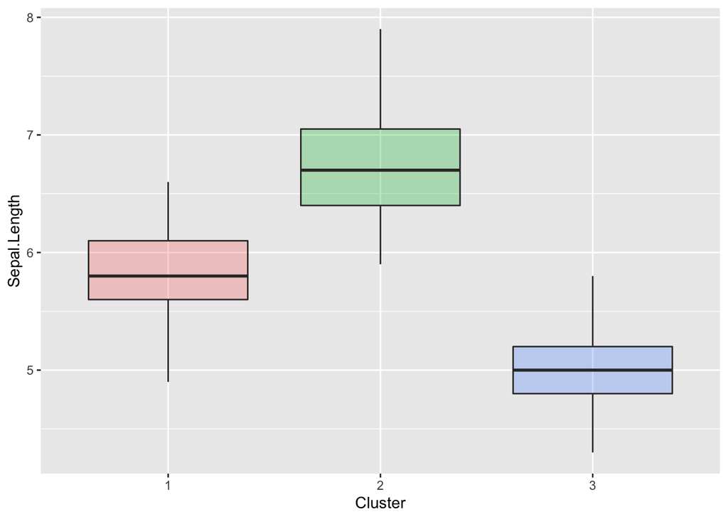

```r
ggplot(out, aes(x=tagged_cluster, y=Sepal.Length,fill=tagged_cluster)) + geom_boxplot(alpha=0.3) +theme(legend.position="none")  + xlab('Cluster')
```

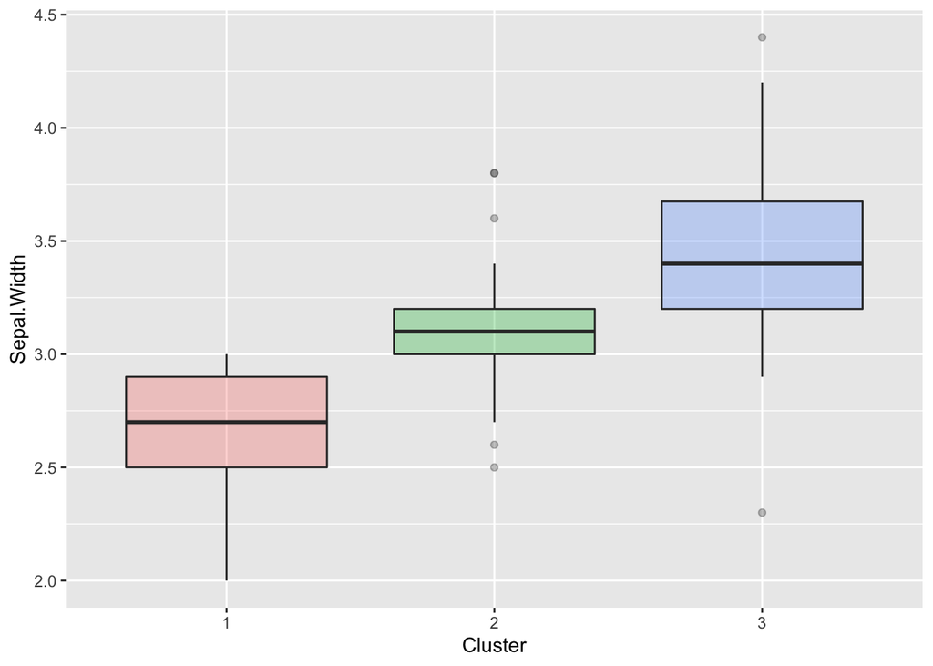

```r
ggplot(out, aes(x=tagged_cluster, y=Sepal.Width,fill=tagged_cluster)) + geom_boxplot(alpha=0.3) +theme(legend.position="none")  + xlab('Cluster')
```

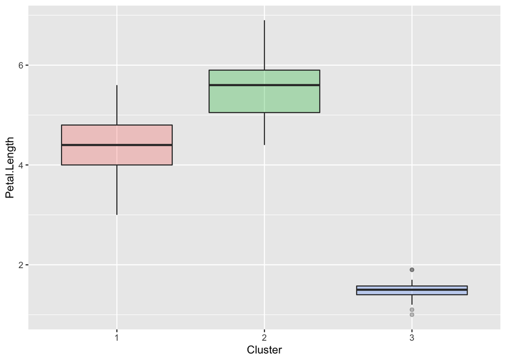

```r
ggplot(out, aes(x=tagged_cluster, y=Petal.Length,fill=tagged_cluster)) + geom_boxplot(alpha=0.3) +theme(legend.position="none")  + xlab('Cluster')
```

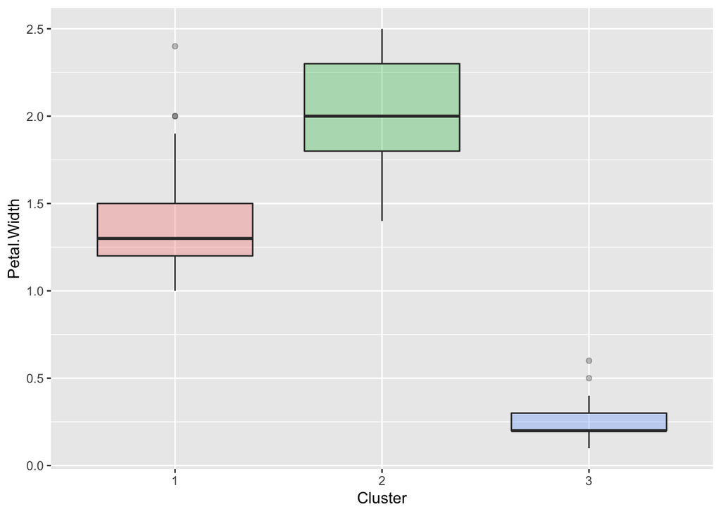

```r
ggplot(out, aes(x=tagged_cluster, y=Petal.Width,fill=tagged_cluster)) + geom_boxplot(alpha=0.3) +theme(legend.position="none")  + xlab('Cluster')
```

**#Analysis**

* As we expected from the density plots and confusion matrix, Petal width and Petal Length are significant discriminator for cluster 3, which is dominated by setosa class. * While the other two variables provide relatively lower discrimination between the clusters.

### Analysis of the misclassified points

```r
classifier_df = out[!out$Species=='setosa',]
classifier_df$status = ''
classifier_df$status[(classifier_df$tagged_cluster=="1" & classifier_df$Species=="versicolor")] = 'improper_versicolor'
classifier_df$status[(classifier_df$tagged_cluster=="2" & classifier_df$Species=="virginica")] = 'improper_virginica'
classifier_df$status[(classifier_df$tagged_cluster=="2" & classifier_df$Species=="versicolor")] = 'proper_versicolor'
classifier_df$status[(classifier_df$tagged_cluster=="1" & classifier_df$Species=="virginica")] = 'proper_virginica'
classifier_df$status<-as.factor(classifier_df$status)
```

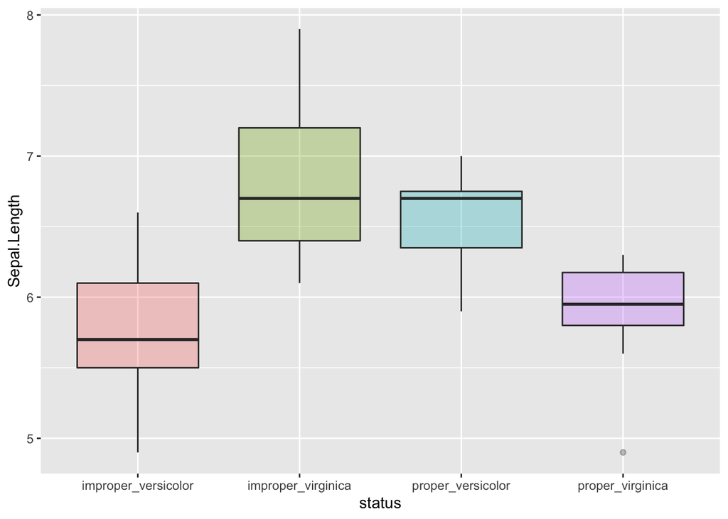

```r
ggplot(classifier_df, aes(x=status, y=Sepal.Length,fill=status)) + geom_boxplot(alpha=0.3) +theme(legend.position="none")
```

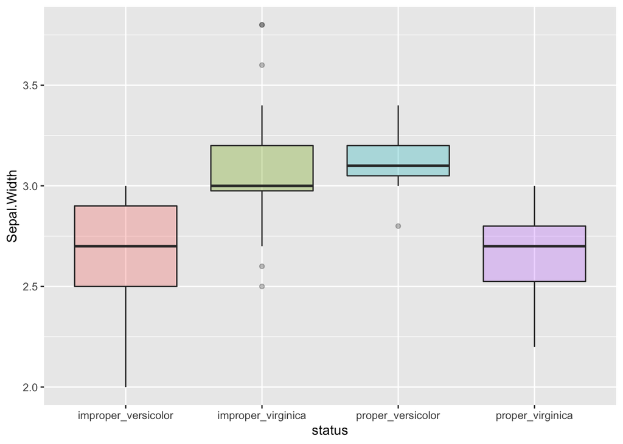

```r
ggplot(classifier_df, aes(x=status, y=Sepal.Width,fill=status)) + geom_boxplot(alpha=0.3) +theme(legend.position="none")
```

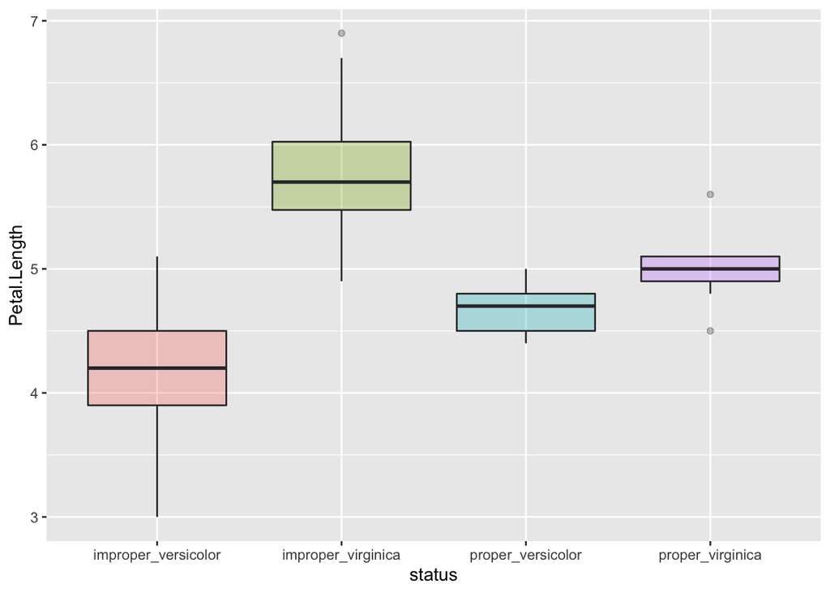

```r
ggplot(classifier_df, aes(x=status, y=Petal.Length,fill=status)) + geom_boxplot(alpha=0.3) +theme(legend.position="none")
```

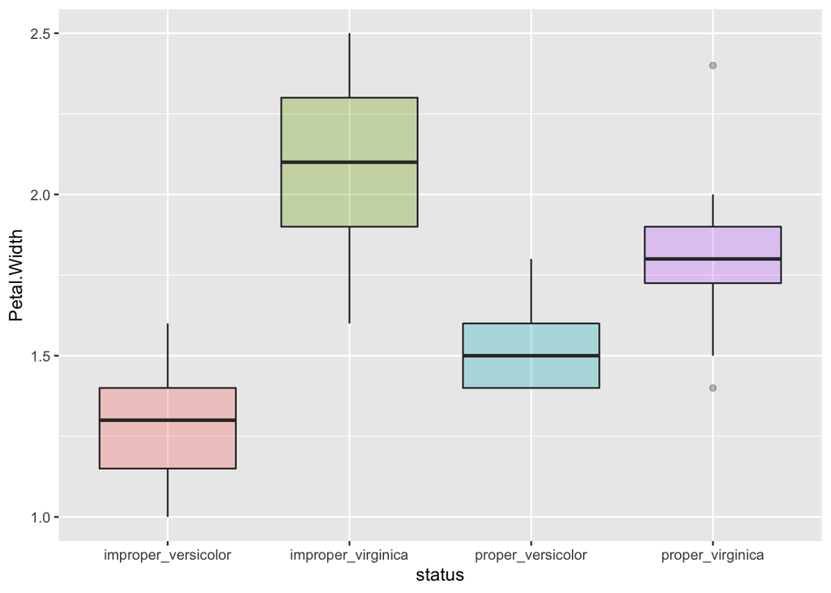

```r
ggplot(classifier_df, aes(x=status, y=Petal.Width,fill=status)) + geom_boxplot(alpha=0.3) +theme(legend.position="none")
```

**#Analysis**

From the above plots, we see: * Distribution of sepal length is very similar for improperly classified versicolor and proper virginica. Similarly, the distribution of improperly classified virginica and proper versicolor are very similar too. * The same effect is apparent in Sepal width. * This apparent similarity can be a probable reason for clustering to confuse between the classes.

```r
# Centroids of Clusters
kmeans_basic_table <- data.frame(best_km$size, best_km$centers)
kmeans_basic_table
```

|  | best_km.size | Sepal.Length | Sepal.Width | Petal.Length | Petal.Width |
| --- | --- | --- | --- | --- | --- |
| 1 | 53 | -0.05005221 | -0.88042696 | 0.3465767 | 0.2805873 |
| 2 | 47 | 1.13217737 | 0.08812645 | 0.9928284 | 1.0141287 |
| 3 | 50 | -1.01119138 | 0.85041372 | -1.3006301 | -1.2507035 |

### Plotting Clusters

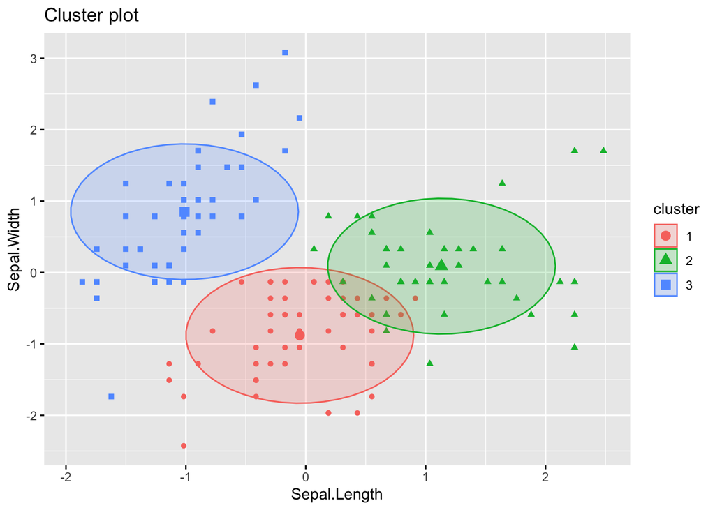

```r
fviz_cluster(best_km, data=scale(iris_data[,1:2]), geom=c("point"), ellipse.type = "euclid")
```

**#Analysis**

* It can be seen from the plot above that cluster 1 and 2 are closely knit (i.e. intra cluster separation is less) and hence we have the confusion in clustering some points for these 2 clusters . Cluster 3 has a better separability than the other 2 and hence it is a good demarcated cluster. * It is also apparent that cluster 3 has higher spread and hence can be split up into 2 clusters depending on the use case which also came up in our previous study (elbow graph to decide between k=3 and k=4)

### Just a visualization with 4 Cluster Space to highlight the above point

```r
alt_kmeans <- kmeans(as.matrix(scale(iris_data[,1:4])), 4, nstart = 25)
alt_kmeans
```

```
## K-means clustering with 4 clusters of sizes 53, 47, 25, 25
##
## Cluster means:
##   Sepal.Length Sepal.Width Petal.Length Petal.Width
## 1  -0.05005221 -0.88042696    0.3465767   0.2805873
## 2   1.13217737  0.08812645    0.9928284   1.0141287
## 3  -0.71894419  1.50198969   -1.2972312  -1.2165934
## 4  -1.30343857  0.19883774   -1.3040289  -1.2848136
##
## Clustering vector:
##   1   2   3   4   5   6   7   8   9  10  11  12  13  14  15  16  17  18  19  20
##   3   4   4   4   3   3   4   4   4   4   3   4   4   4   3   3   3   3   3   3
##  21  22  23  24  25  26  27  28  29  30  31  32  33  34  35  36  37  38  39  40
##   3   3   3   4   4   4   4   3   3   4   4   3   3   3   4   4   3   3   4   4
##  41  42  43  44  45  46  47  48  49  50  51  52  53  54  55  56  57  58  59  60
##   3   4   4   3   3   4   3   4   3   4   2   2   2   1   1   1   2   1   1   1
##  61  62  63  64  65  66  67  68  69  70  71  72  73  74  75  76  77  78  79  80
##   1   1   1   1   1   2   1   1   1   1   2   1   1   1   1   2   2   2   1   1
##  81  82  83  84  85  86  87  88  89  90  91  92  93  94  95  96  97  98  99 100
##   1   1   1   1   1   2   2   1   1   1   1   1   1   1   1   1   1   1   1   1
## 101 102 103 104 105 106 107 108 109 110 111 112 113 114 115 116 117 118 119 120
##   2   1   2   2   2   2   1   2   2   2   2   2   2   1   1   2   2   2   2   1
## 121 122 123 124 125 126 127 128 129 130 131 132 133 134 135 136 137 138 139 140
##   2   1   2   1   2   2   1   2   2   2   2   2   2   1   1   2   2   2   1   2
## 141 142 143 144 145 146 147 148 149 150
##   2   2   1   2   2   2   1   2   2   1
##
## Within cluster sum of squares by cluster:
## [1] 44.087545 47.450194 12.147537  9.646348
##  (between_SS / total_SS =  81.0 %)
##
## Available components:
##
## [1] "cluster"      "centers"      "totss"        "withinss"     "tot.withinss"
## [6] "betweenss"    "size"         "iter"         "ifault"
```

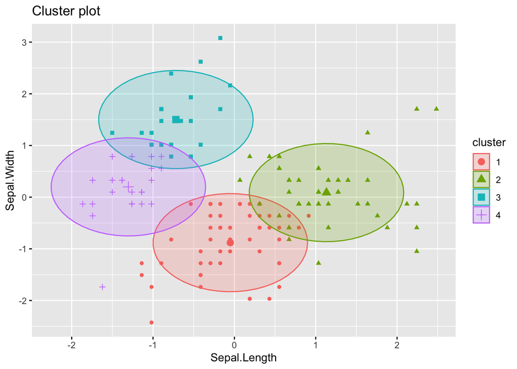

```r
fviz_cluster(alt_kmeans, data=scale(iris_data[,1:2]), geom=c("point"), ellipse.type = "euclid")
```

### Accuracy in individual classes (to see how well clustering predicts flower type)

```r
acc_versicolor = 1 - (11/50)
acc_virginica = 1 - (14/50)
acc_setosa = 1- (0/50)

print (paste("Acc for versicolor",acc_versicolor))
```

```
## [1] "Acc for versicolor 0.78"
```

```r
print (paste("Acc for virginica",acc_virginica))
```

```
## [1] "Acc for virginica 0.72"
```

```r
print (paste("Acc for setosa",acc_setosa))
```

```
## [1] "Acc for setosa 1"
```

**#Analysis**

Thus we have 100% accuracy for setosa, while for the other two flowers we have accuracy in 70’s.